# US Presidential 2016 - California

by E. Rabaute

### I) Objectives

The objective of this analysis is to provide valuable information about 2016 US presidential campaign donation using data analysis methods and tools.

RStudio will be used for data wrangling, and data explonary analysis.

This project is the last task validating Udacity explonary analysis MOOC.

### II) Data analysed

#### a) Format and volume

The data used for this analysis is a csv file downloaded from http://classic.fec.gov/ related from campaign Finance in Calfornia state.

Data size: ~250 MB Type: CSV file (comma separation)

Rows: 1 304 346

In order to accelerate computation for exploratory analysis, I’d sample all the data around 10%. Then, once all code and plots were generated, I computed all data.

```
##  [1] "cmte_id"           "cand_id"           "cand_nm"
##  [4] "contbr_nm"         "contbr_city"       "contbr_st"
##  [7] "contbr_zip"        "contbr_employer"   "contbr_occupation"
## [10] "contb_receipt_amt" "contb_receipt_dt"  "receipt_desc"
## [13] "memo_cd"           "memo_text"         "form_tp"
## [16] "file_num"          "tran_id"           "election_tp"
```

#### b) Summary of main variables

- contb_receipt_dt -> date of contrubtion

There are peaks: - first one during primairs - second one at the moment of conventions (republicans and democrats) - The last one at the moment of general elections

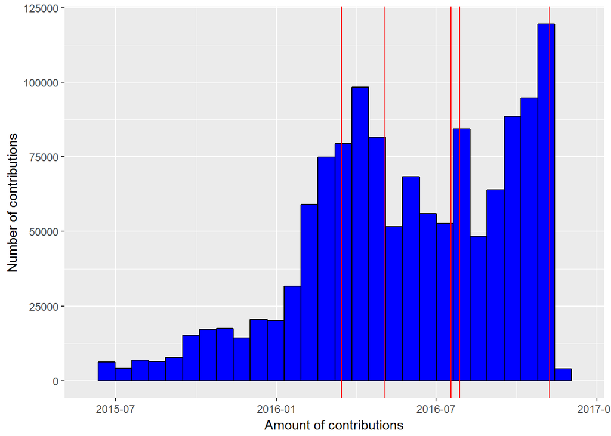

- cand_nm -> Name of the candidates

```
##                 Bush, Jeb       Carson, Benjamin S.
##                      3130                     27370
##  Christie, Christopher J.   Clinton, Hillary Rodham
##                       333                    688524
## Cruz, Rafael Edward 'Ted'            Fiorina, Carly
##                     57822                      4706
##      Gilmore, James S III        Graham, Lindsey O.
##                         3                       347
##            Huckabee, Mike             Jindal, Bobby
##                       531                        31
##             Johnson, Gary           Kasich, John R.
##                      1758                      3005
##          Lessig, Lawrence            McMullin, Evan
##                       372                       306
##   O'Malley, Martin Joseph         Pataki, George E.
##                       397                        20
##                Paul, Rand    Perry, James R. (Rick)
##                      4279                       116
##              Rubio, Marco          Sanders, Bernard
##                     14095                    407164
##      Santorum, Richard J.               Stein, Jill
##                        91                      2842
##          Trump, Donald J.             Walker, Scott
##                     86258                       740
##     Webb, James Henry Jr.
##                       106
```

- contb_receipt_amt -> Amount of the contribution

```
##     Min.  1st Qu.   Median     Mean  3rd Qu.     Max.
## -10500.0     15.0     27.0    116.2     88.0  10800.0
```

The same variable with an histogram -> Looks like a positive skewed distribution

We can see that peaks are for rounded amount (‘50’, ‘100’, ‘150’, ‘200’)

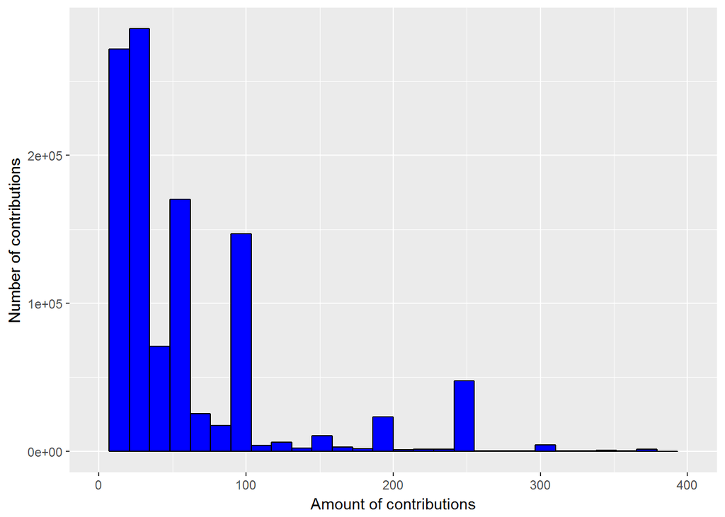

- contb_receipt_city -> City where the contribution was done

```
##       LOS ANGELES     SAN FRANCISCO         SAN DIEGO           OAKLAND
##            102710             90937             46129             33235
##          SAN JOSE        SACRAMENTO          BERKELEY        LONG BEACH
##             30674             23799             23150             15757
##      SANTA MONICA          PASADENA         PALO ALTO     SANTA BARBARA
##             14495             12865             12105             11999
##        SANTA CRUZ        SANTA ROSA            FRESNO            IRVINE
##             11504             11314              8907              8496
##      WALNUT CREEK    WEST HOLLYWOOD      SHERMAN OAKS         SUNNYVALE
##              8233              8121              7648              7349
##             DAVIS        SAN RAFAEL     MOUNTAIN VIEW  HUNTINGTON BEACH
##              7108              7044              7012              6889
##     BEVERLY HILLS         RIVERSIDE           ALAMEDA          GLENDALE
##              6796              6574              6513              6275
##       BAKERSFIELD      PALM SPRINGS       MILL VALLEY         SAN MATEO
##              6145              6041              5988              5981
##           BURBANK           VENTURA          CARLSBAD       STUDIO CITY
##              5883              5393              5384              5364
##        MENLO PARK     NEWPORT BEACH          PETALUMA      REDWOOD CITY
##              5342              5252              5207              5169
##              NAPA           FREMONT           ANAHEIM         OCEANSIDE
##              5025              4927              4786              4618
##          TORRANCE PACIFIC PALISADES            NOVATO     REDONDO BEACH
##              4596              4593              4544              4535
##            VENICE            ENCINO        SEBASTOPOL         LOS ALTOS
##              4437              4432              4410              4393
##       CULVER CITY          LA JOLLA    WOODLAND HILLS         SANTA ANA
##              4378              4355              4333              4285
##         LOS GATOS         ESCONDIDO          RICHMOND          STOCKTON
##              4261              4132              4065              4034
##             CHICO   NORTH HOLLYWOOD       SANTA CLARA           CONCORD
##              3986              3976              3852              3793
##         LIVERMORE     THOUSAND OAKS            ORANGE       CHULA VISTA
##              3775              3735              3721              3641
##         LAFAYETTE         ENCINITAS          ALTADENA           MODESTO
##              3600              3580              3551              3398
##          DANVILLE      LAGUNA BEACH     LAGUNA NIGUEL         ROSEVILLE
##              3379              3373              3342              3322
##        COSTA MESA          VAN NUYS        EL CERRITO     MISSION VIEJO
##              3311              3309              3297              3277
##   MANHATTAN BEACH         CUPERTINO            OXNARD        PLEASANTON
##              3254              3204              3175              3149
##       PALM DESERT          PACIFICA           HAYWARD         CAMARILLO
##              3095              3073              3072              3068
##         FULLERTON   SAN LUIS OBISPO           VALLEJO            ALBANY
##              3059              3051              3043              3022
##         ELK GROVE        CARMICHAEL    MARINA DEL REY         CLAREMONT
##              3019              3016              2998              2920
##      GRASS VALLEY       SIMI VALLEY             VISTA           (Other)
##              2856              2834              2828            475466
```

- contbr_employer -> employer of contribution

```
##                                    N/A
##                                 185382
##                                RETIRED
##                                 121569
##                          SELF-EMPLOYED
##                                 120187
##                                   NONE
##                                  84297
##                           NOT EMPLOYED
##                                  50821
##                          SELF EMPLOYED
##                                  38881
##                                   SELF
##                                  36395
##                  INFORMATION REQUESTED
##                                  30412
##
##                                  10522
##                    STATE OF CALIFORNIA
##                                   5884
##                                 GOOGLE
##                                   5002
##                      KAISER PERMANENTE
##                                   4769
## INFORMATION REQUESTED PER BEST EFFORTS
##                                   4205
##                              HOMEMAKER
##                                   4160
##                    STANFORD UNIVERSITY
##                                   3864
##                                   UCLA
##                                   3320
##               UNIVERSITY OF CALIFORNIA
##                                   3150
##                             APPLE INC.
##                                   2646
##    LOS ANGELES UNIFIED SCHOOL DISTRICT
##                                   2222
##                     LOS ANGELES COUNTY
##                                   1605
```

[output cut: 145 more lines]

```
##                                    387
##                                  FEDEX
##                                    385
##                                  SFUSD
##                                    385
##                         POMONA COLLEGE
##                                    376
##      SAN DIEGO UNIFIED SCHOOL DISTRICT
##                                    376
##                   SANTA MONICA COLLEGE
##                                    374
##                                (Other)
##                                 529810
##                                   NA's
##                                    679
```

#### c) Correlations

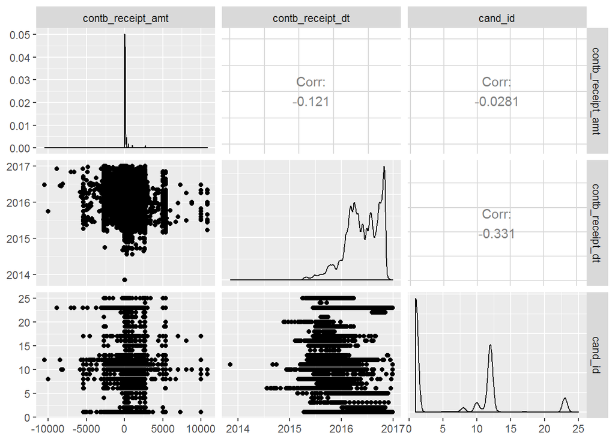

### III) First observations

#### a) Number of donators for each candidate

The first step is to assess the number of donators for each candidates.

The Y axis is in log10 scale as there is a huge difference between all candidates (Mr Gilmore vs Mrs Clinton)

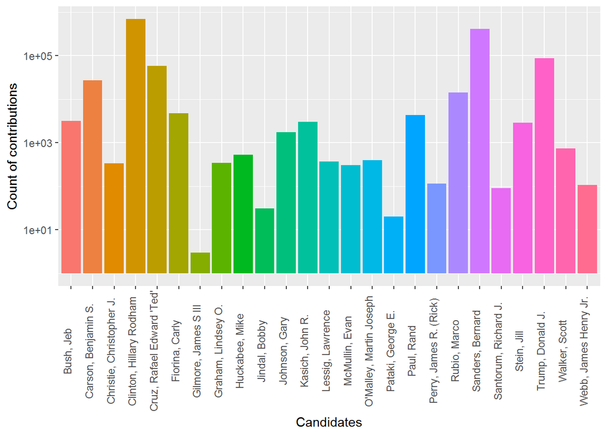

The most interesting information we can get from this plot are:

- Huge difference between candidates (Mr Gilmore vs Mrs Clinton)
- The relative low count of donations for Mr Trump (that was confirmed by a low score in popular vote: 32% vs 62% for Mrs Clinton ) that confirms that California was a “democrat”" state

#### b) Amount of donations for each candidate

The next step is to assess the amount and no more the count of donations for each candidates.

The next scatter plot shows all donations for each candidats all along the campaign with the amount as Y axis.

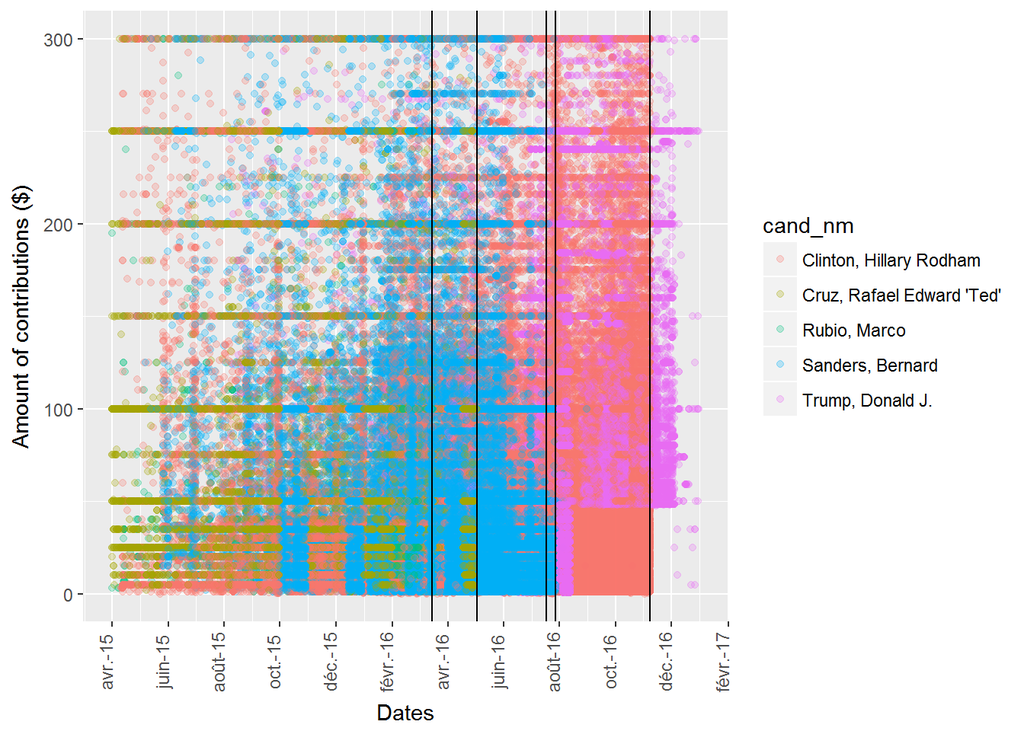

Elections time line:

- 08-11-16: General US presidential elections,
- 28-07-16: Democrats convention,
- 18-07-16: Republicans convention,
- 3-05-16: Mr Sanders stop,
- 15-03-16 : Mr Rubio stop

The most interesting information we can get from this plot are:

- The different steps (straight lines) corresponding to certain rounded values
- 10, 25, 50, 75, 100, 150, 200, 250, 300
- The main colors depending on the date
- Mr Sanders from Oct. 15 to August 15, Mrs Clinton from Democrat convention to Election date and Mr trump at the very last stage of the campaign (ie.: after the general elections)

On the next plot, I focused on the total amount of donations for the main candidates.

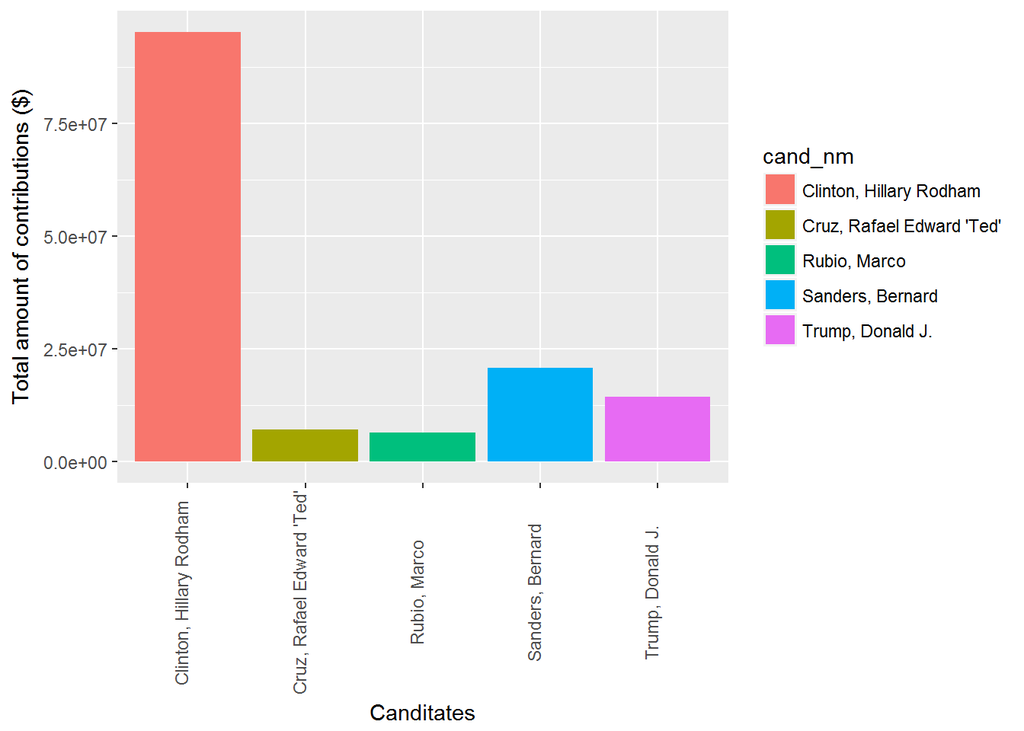

The most interesting information we can get from this plot are:

- As for the count of donations, the total amount is far greater for Mrs Clinto than others
- Low score for Mr Trump (lower than Mr Sanders) despite being elected in national elections at the end

#### c) Amount of donations percontributors for main candidates

in the next plot, we can see the distribution of donation amounts for main candidates.

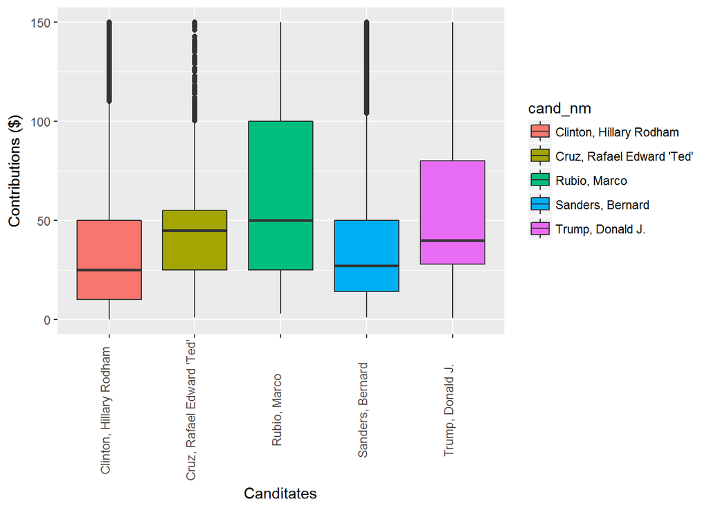

The most interesting information we can get from this box plot are:

- Mr Rubio contributors seem to spend more money than other candidates
- Mrs Clinton contributors seem to spend less money than other candidates

What could we assume about that observations:

- Are Mrs clinton’s contributors poorer than for other canditates?
- Are Mrs Clinton’s contibutors less committed than for other canditates?

To answer this questions, we should have other informations like:

- Revenue of contributors
- % satisfaction about the candidate for each contributors

#### d) Focus on finalists

The next table shows for both finalists the total sum and count of donations.

```
##                              Sum        n
## Clinton, Hillary Rodham 93681171   688524
## Trump, Donald J.        14006381    86258
```

We have a confirmation that Mrs Clinton receive much more money for her contributors.

The next box plot confirms that mean donations are higher for Mr Trump than Mrs Clinton.

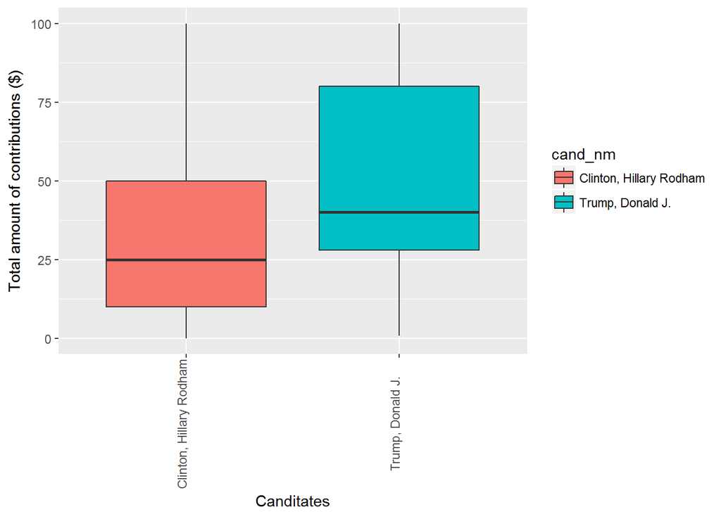

### IV) Detailed plots

#### a) Evolution of donations for main candiates vs election time line

In the next chart, we can superpose the amount of donations all along the election.

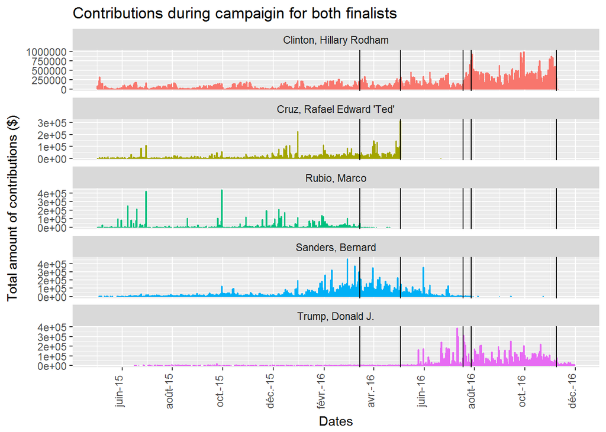

We can see that we have a clear correlation between donations and some milestone of the elections.

For instance, Mr Sanders donations lowered after his capaign stop and completely vanished after Democrats convention.

Another example is Mr Cruz with a clear stop of donations after his renonciation announcement.

#### b) Evolution of donations for finalists vs election time line

The same plot focused for finalists that confirm last analysis.

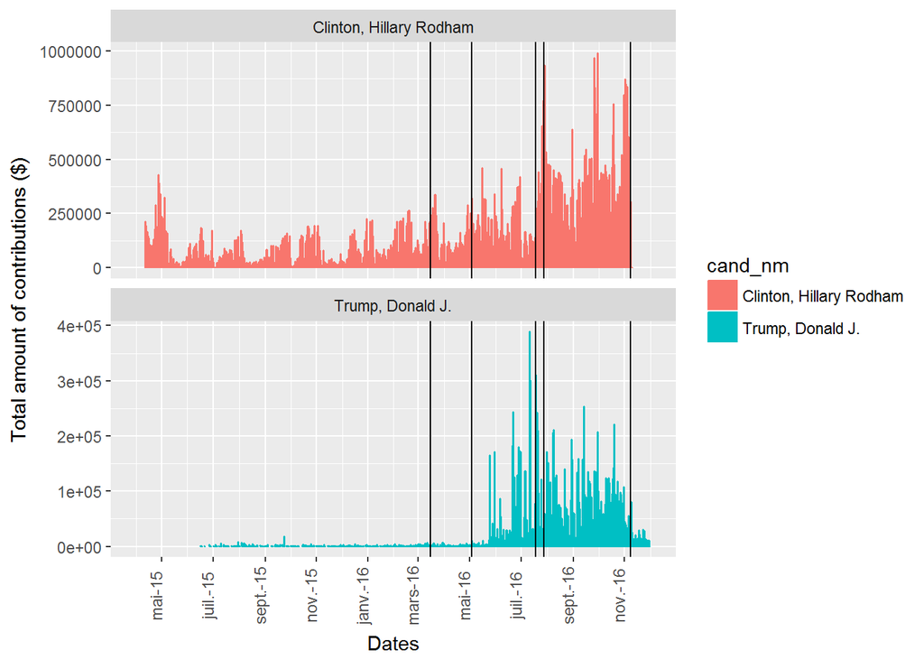

#### c) Contributor occupation for finalists

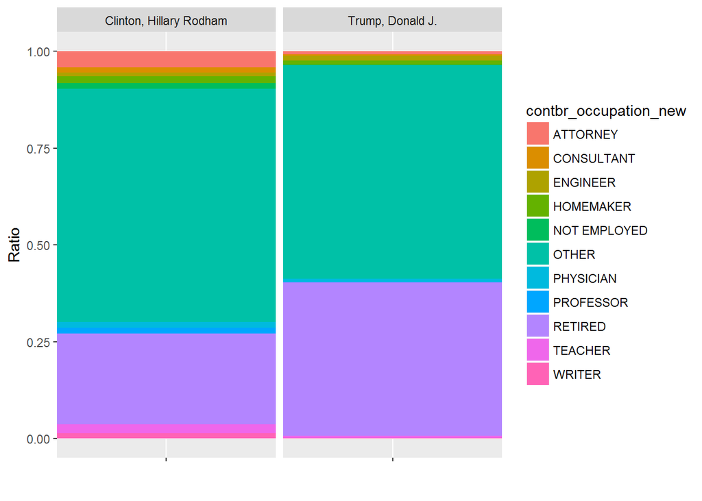

The same information is displayed in the following plot.

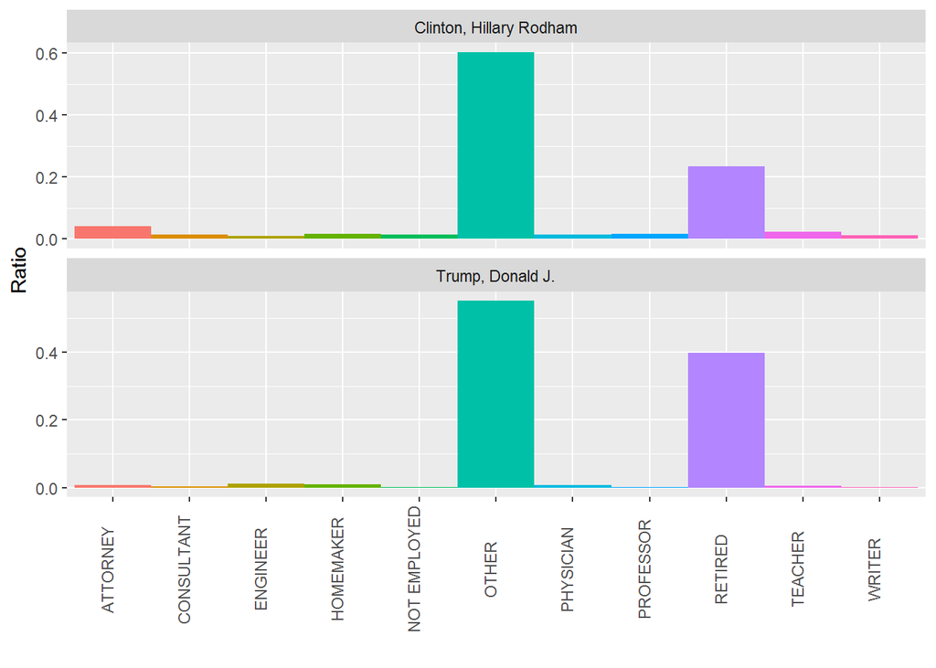

I propose to highlight the top 10 for both finalists.

```
##    Clinton, Hillary Rodham Trump, Donald J.
## 1  "RETIRED"               "RETIRED"
## 2  "ATTORNEY"              "SELF-EMPLOYED"
## 3  "TEACHER"               "SALES"
## 4  "HOMEMAKER"             "ENGINEER"
## 5  "PROFESSOR"             "HOMEMAKER"
## 6  "PHYSICIAN"             "BUSINESS OWNER"
## 7  "NOT EMPLOYED"          "PHYSICIAN"
## 8  "CONSULTANT"            "ATTORNEY"
## 9  "WRITER"                "CEO"
## 10 "ENGINEER"              "MANAGER"
```

#### d) Contributor city for finalists

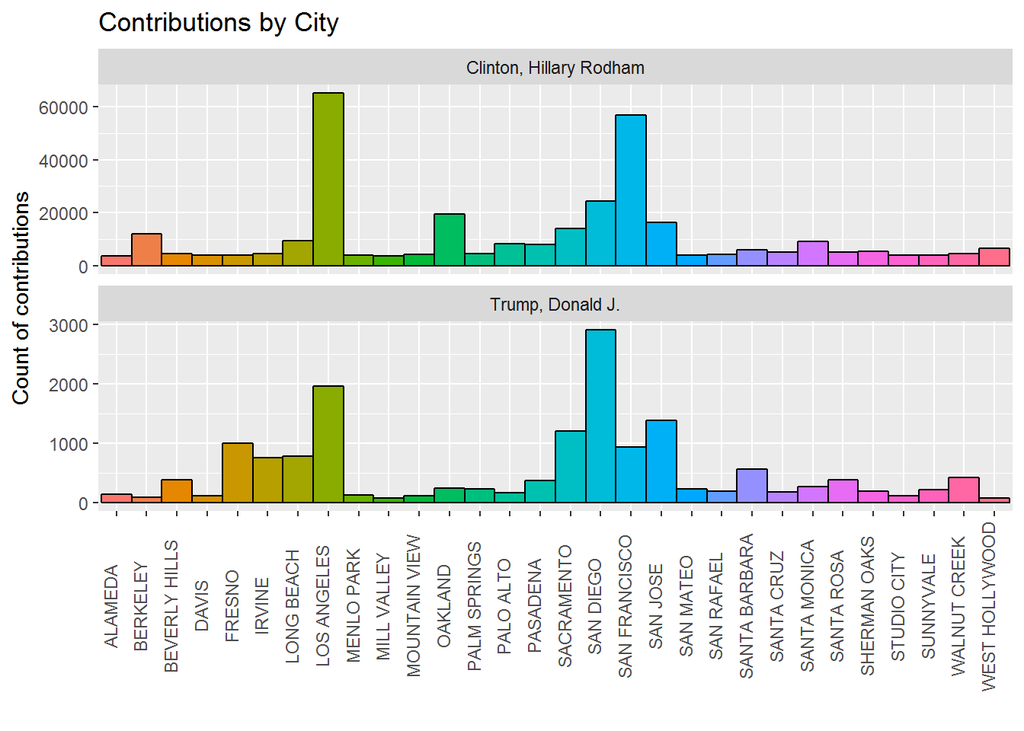

We can notice that:

- Bigger are the city more contributors we have. That is normal.
- On the other hand, we can notice that San Diego, San jose and Fresno are over represented in Mr Trump contributors
- In opposite way, Los Angeles and San Francisco are under represented (inn comparison with city populations)
- For Mrs Clinton, Biggest city as Los Angeles and San Franciso represents the main part of contributors. Oakland is big provider as well

The following plots will illustrate the same information in a more graphical view.

In a the first plot, we analyse Los Angeles map with number of conrtibutions.

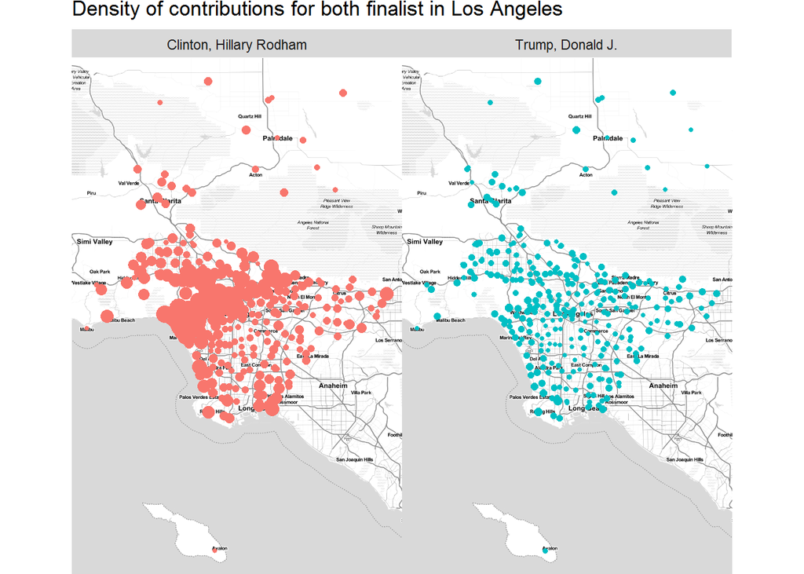

In the next plot, the same information are represented for San Diego that is the city where Mr Trump contributors were the most present (even if less numberous than Mrs Clinton’s one)

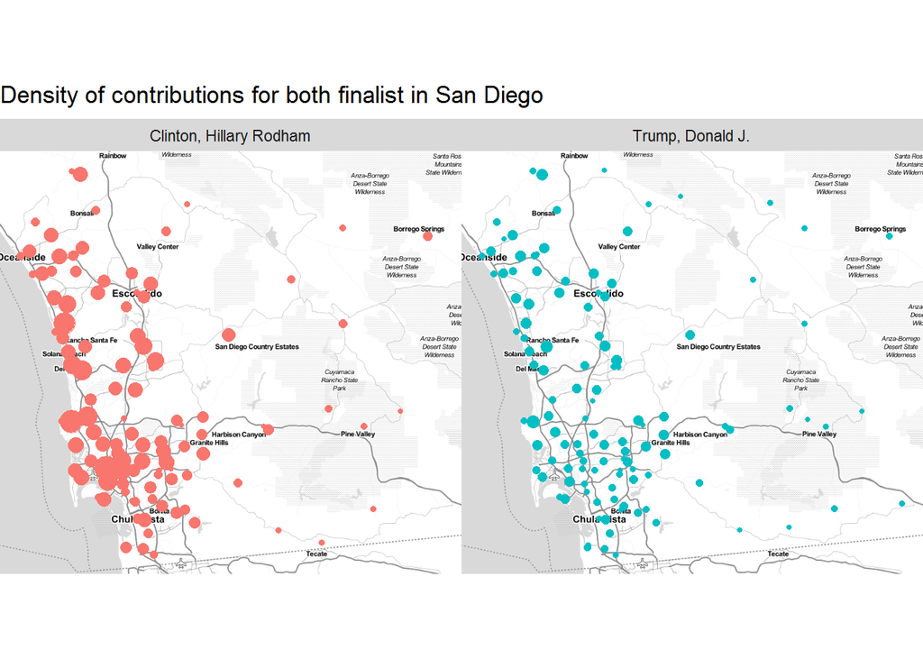

On the last map, we have represented all California State.

Nothing special is to be noticed in this plot.

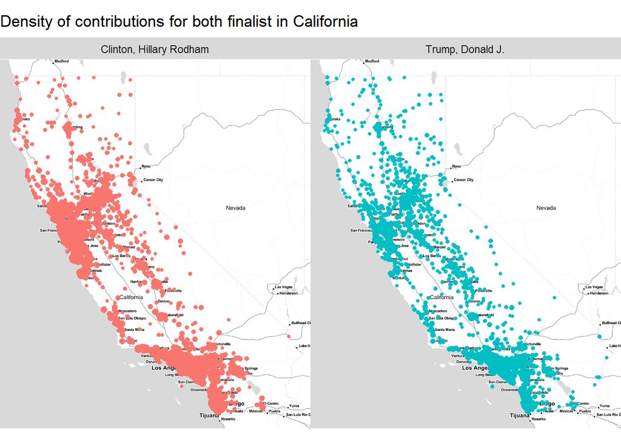

#### e) Contributor employer for finalists

I propose to look at contribution distribution per employers.

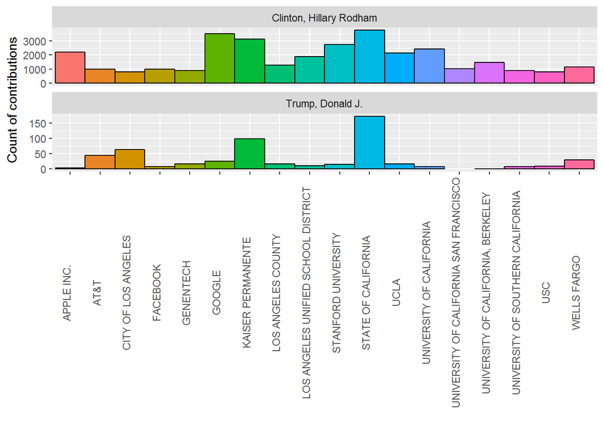

We can notice that:

- State of California is one of biggest employer in California and so well represented for both finalists
- On the other hand, GAFA (Google, Apple and Facebook) are mainly represented in Mrs Clinton contirbutions (see following plot)

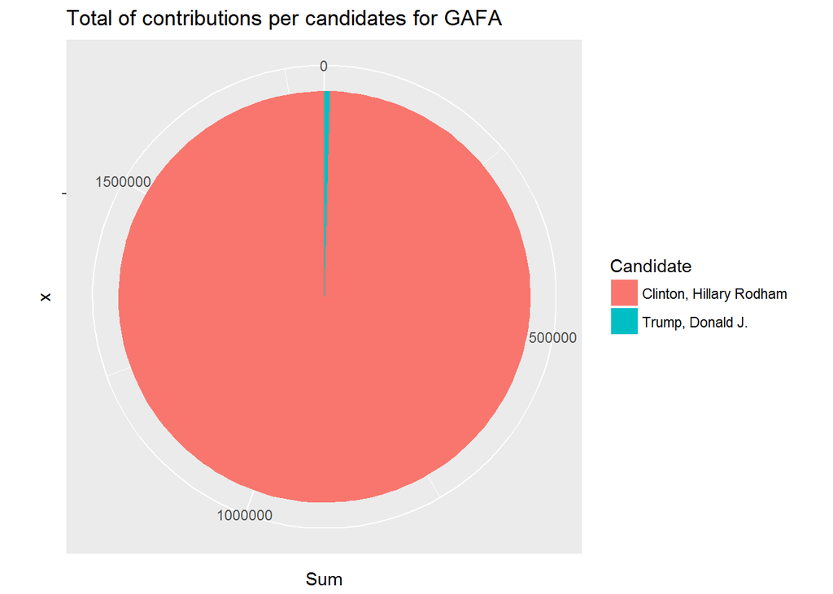

We can in the previous chart that GAFA contributors are for Mrs Clinton at an excessive rate (>99%)

### V) Summary

In this analysis, we have highligthed that:

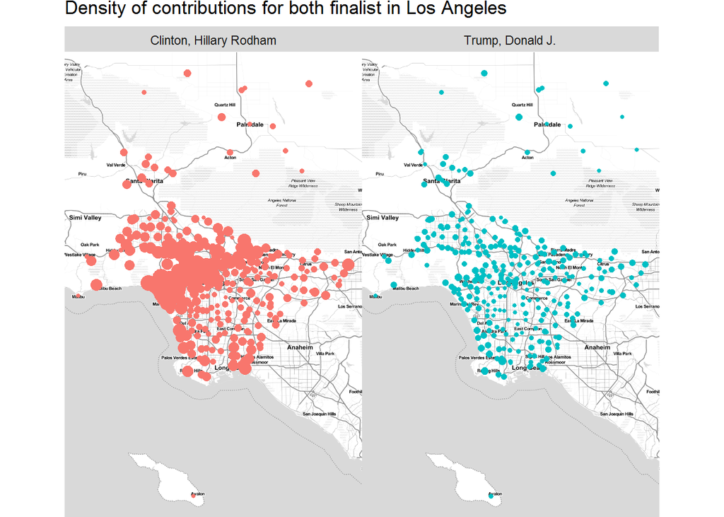

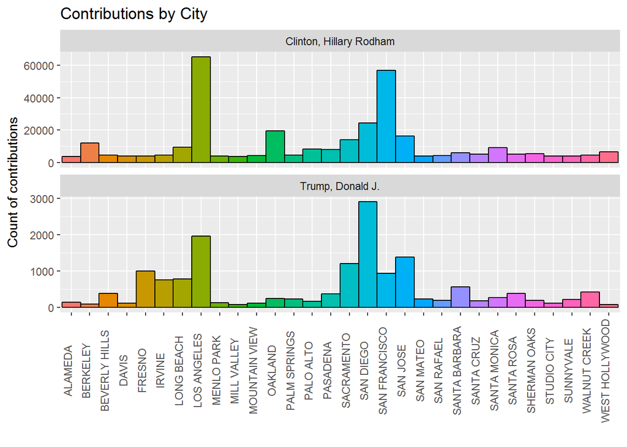

- When we compare contribution vs campaign timeline we can a real correlation between donations and candidates status (running, suspended or stopped) (see following plot)

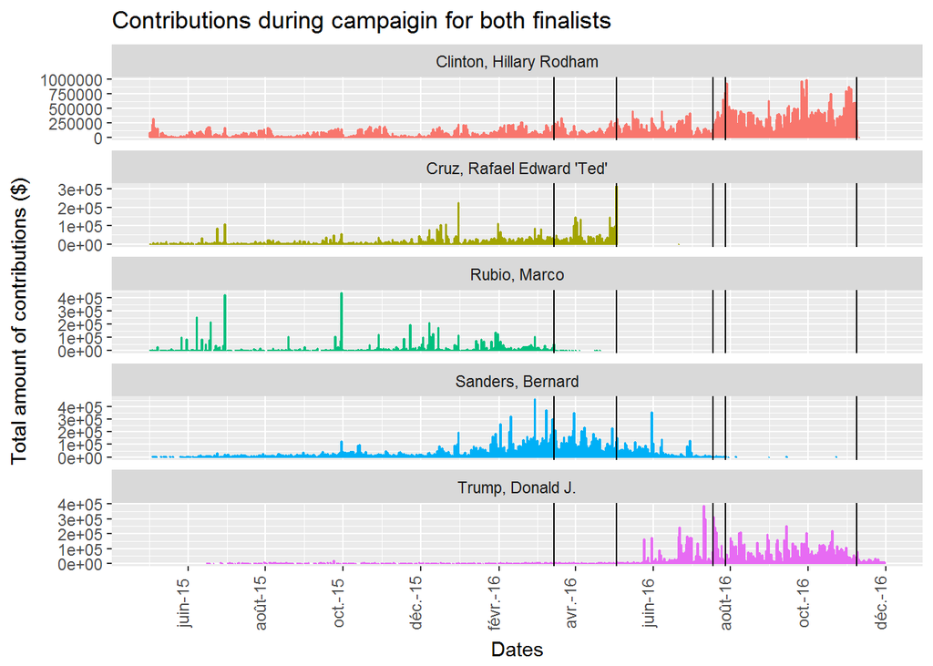

‘08-11-16’: General US presidential elections ‘28-07-16’: Democrats convention ‘18-07-16’: Republicans convention ‘3-05-16’: Mr Sanders stop ‘15-03-16’ : Mr Rubio stop

### VI) Reflection

With this limited dataset, we cannot conclude on several questions:

- How social, ethnic, religion or cultural environments impact the choice of candidate?
- We could add information about revenue for example
- How satisfaction about selected candidate impact the contribution especially after conventions?
- We could add a collumn in the dataframe with candidates polls

Regarding struggles and successes, I can highlith:

- It was very difficult to use some R api, I find documentation about R library non exhaustive and sometime frustrating
- Map visualization was quite easy to use

For me, R can be very powerful because we can display very interesting plots and charts in a short time frame. On the other hand, R becomes very difficult to use as soon as errors are raised as no complete documentations is available. Only help can come from Forums and it is why I did intensively once I got some big issues on my code.